# Lab 8: Bivariate Mapping in R

Michael Allman

4/29/21

## Downloading data

**1. Use `tidycensus` to download 1. race/ethnicity (B03002) and 2. median household income for Baltimore City. Store this data in a new object. Choose which race/ethnicity you’d like to relate to income (Non-Hispanic Black and Non-Hispanic White work best). Which census tract has the highest *percentage* of your target race/ethnicity (and what is the percent) and which has the highest median household income (and how much is it?)? (5 points)** Reminder: Since we will be mapping our data, make sure you include use `geometry = TRUE` in `get_acs()`

```r
# Download total population, population of Blacks, and median household income ACS 2019 Census data from https://www.socialexplorer.com/data/ACS2019_5yr/metadata/?ds=ACS19_5yr for Maine tracts.
Balt_income_race = get_acs(geography = "tract",
      variables = c("total_pop" = "B03002_001",# Total population
                    "Blck_NonH" = "B03002_004", # Non-Hispanic Black population
                    "income" = "B19013_001"), # Median household income
      year = 2019,
survey = "acs5",
state = c(24),  # FIPS code for Maryland
county = c(510), # FIPS code for Baltimore City
geometry = TRUE,
output = "wide")
# Compute the percent of the population that is Black.
Balt_income_race$Percent_Blck = (Balt_income_race$Blck_NonHE / Balt_income_race$total_popE)

# Create a sf object.
st_as_sf(Balt_income_race)
```

```
## Simple feature collection with 200 features and 9 fields
## geometry type:  MULTIPOLYGON
## dimension:      XY
## bbox:           xmin: -76.71152 ymin: 39.19721 xmax: -76.52945 ymax: 39.3722
## geographic CRS: NAD83
## First 10 features:
##          GEOID                                           NAME total_popE
## 1  24510260202 Census Tract 2602.02, Baltimore city, Maryland       5681
## 2  24510150100    Census Tract 1501, Baltimore city, Maryland       2172
## 3  24510250303 Census Tract 2503.03, Baltimore city, Maryland       2229
## 4  24510180100    Census Tract 1801, Baltimore city, Maryland       2185
## 5  24510020300     Census Tract 203, Baltimore city, Maryland       3761
## 6  24510250402 Census Tract 2504.02, Baltimore city, Maryland       4614
## 7  24510150600    Census Tract 1506, Baltimore city, Maryland       2726
## 8  24510260102 Census Tract 2601.02, Baltimore city, Maryland       4775
```

[output cut: 24 more lines]

**2. Which census tract has the highest percentage of Black people? (and what is the percent) and which has the highest median household income (and how much is it?)? (5 points)**

```r
Balt_income_race %>%
  filter(Percent_Blck == max(Percent_Blck, na.rm = TRUE))
```

```
## Simple feature collection with 1 feature and 9 fields
## geometry type:  MULTIPOLYGON
## dimension:      XY
## bbox:           xmin: -76.68081 ymin: 39.28109 xmax: -76.67217 ymax: 39.28816
## geographic CRS: NAD83
##         GEOID                                           NAME total_popE
## 1 24510200702 Census Tract 2007.02, Baltimore city, Maryland       1026
##   total_popM Blck_NonHE Blck_NonHM incomeE incomeM
## 1        227       1019        227   44830    2924
##                         geometry Percent_Blck
## 1 MULTIPOLYGON (((-76.68081 3...    0.9931774
```

```r
Balt_income_race %>%
  filter(incomeE == max(incomeE, na.rm = TRUE))
```

```
## Simple feature collection with 1 feature and 9 fields
## geometry type:  MULTIPOLYGON
## dimension:      XY
## bbox:           xmin: -76.62923 ymin: 39.33853 xmax: -76.60958 ymax: 39.35387
## geographic CRS: NAD83
##         GEOID                                           NAME total_popE
## 1 24510271102 Census Tract 2711.02, Baltimore city, Maryland       4597
##   total_popM Blck_NonHE Blck_NonHM incomeE incomeM
## 1        501        992        183  195156   48413
##                         geometry Percent_Blck
## 1 MULTIPOLYGON (((-76.62923 3...    0.2157929
```

```r
# 1.) The tract with the largest percentage of Black people, which equals 99.32%, is number 2007.02. The tract with the highest median house hold income is number 2711.02 and equals $195,156.
```

**2. Please reproject this data to Web Mercator. (1 points)**

```r
Balt_income_race = st_transform(Balt_income_race, crs = 3857)

st_crs(Balt_income_race)
```

```
## Coordinate Reference System:
##   User input: EPSG:3857
##   wkt:
## PROJCRS["WGS 84 / Pseudo-Mercator",
##     BASEGEOGCRS["WGS 84",
##         DATUM["World Geodetic System 1984",
##             ELLIPSOID["WGS 84",6378137,298.257223563,
##                 LENGTHUNIT["metre",1]]],
##         PRIMEM["Greenwich",0,
##             ANGLEUNIT["degree",0.0174532925199433]],
##         ID["EPSG",4326]],
##     CONVERSION["Popular Visualisation Pseudo-Mercator",
##         METHOD["Popular Visualisation Pseudo Mercator",
##             ID["EPSG",1024]],
##         PARAMETER["Latitude of natural origin",0,
##             ANGLEUNIT["degree",0.0174532925199433],
##             ID["EPSG",8801]],
##         PARAMETER["Longitude of natural origin",0,
##             ANGLEUNIT["degree",0.0174532925199433],
##             ID["EPSG",8802]],
##         PARAMETER["False easting",0,
##             LENGTHUNIT["metre",1],
##             ID["EPSG",8806]],
##         PARAMETER["False northing",0,
##             LENGTHUNIT["metre",1],
##             ID["EPSG",8807]]],
##     CS[Cartesian,2],
##         AXIS["easting (X)",east,
##             ORDER[1],
##             LENGTHUNIT["metre",1]],
##         AXIS["northing (Y)",north,
##             ORDER[2],
##             LENGTHUNIT["metre",1]],
##     USAGE[
##         SCOPE["unknown"],
##         AREA["World - 85Â°S to 85Â°N"],
##         BBOX[-85.06,-180,85.06,180]],
##     ID["EPSG",3857]]
```

**3. Create two plots. In the first plot highlight the tract with the highest concentration of your selected race/eth. In the second plot highlight the tract with the highest median household income? (5 points)**

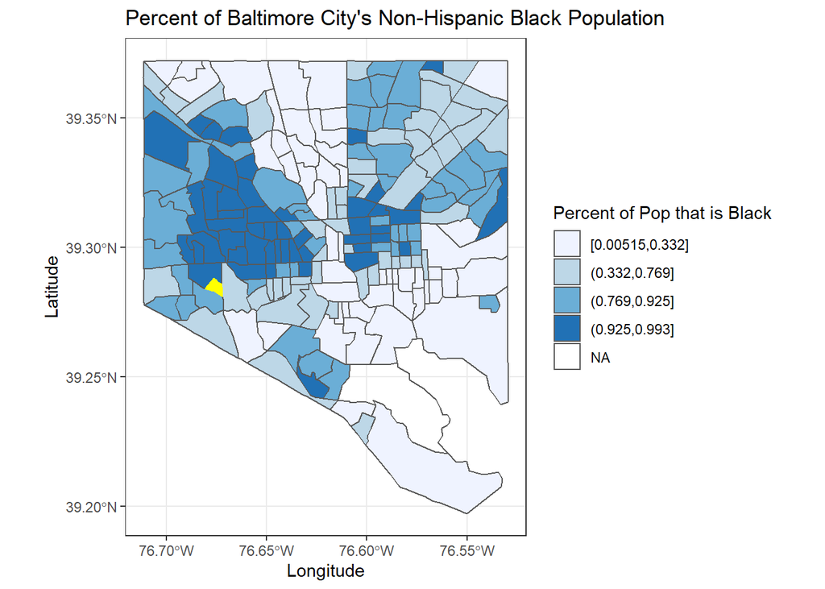

```r
library(dplyr)

# Define a variable equivalent to the tract with the highest Black percentage.
Max_percent = Balt_income_race %>%
  filter(Percent_Blck == max(Percent_Blck, na.rm = TRUE))

ggplot(Balt_income_race) +
  geom_sf(aes(fill = cut_number(Percent_Blck, 4))) +
  geom_sf(data = Max_percent, color = "yellow", fill = "yellow") +
  scale_fill_brewer(type = "seq", palette = 1,
                    name = "Percent of Pop that is Black") +
  labs(title = "Percent of Baltimore City's Non-Hispanic Black Population") +
  xlab("Longitude") +
  ylab("Latitude") +
  theme_bw()
```

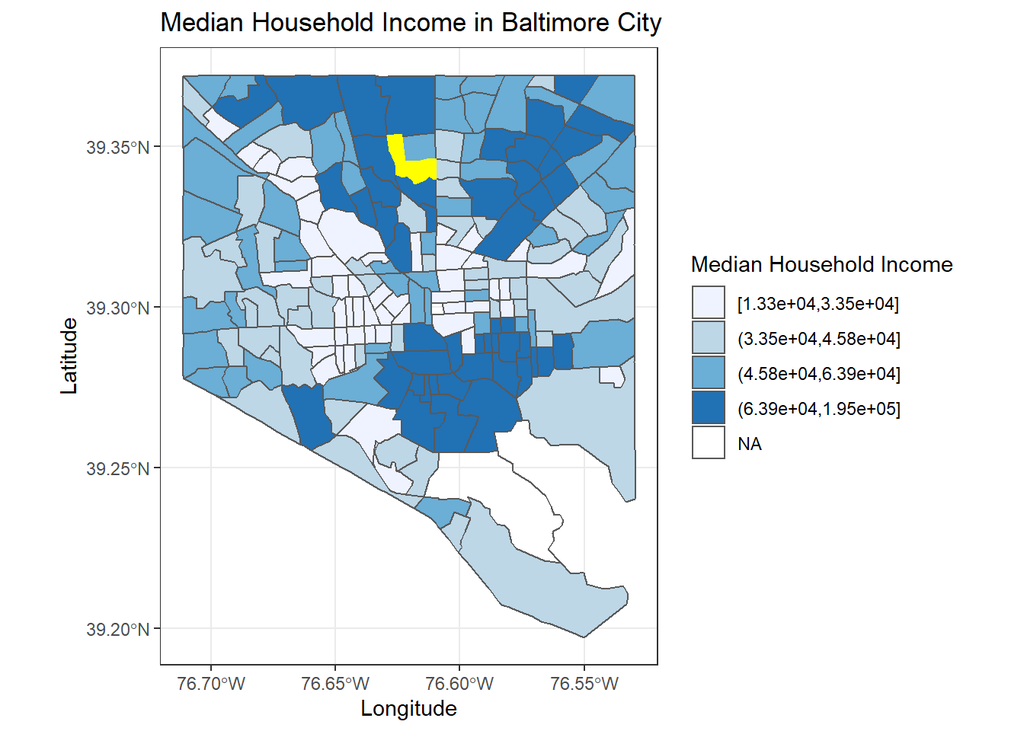

```r
# Define a variable equivalent to the tract with the highest median income.
Max_income = Balt_income_race %>%
  filter(incomeE == max(incomeE, na.rm = TRUE))

ggplot(Balt_income_race) +
  geom_sf(aes(fill = cut_number(incomeE, 4))) +
  geom_sf(data = Max_income, color = "yellow", fill = "yellow") +
  scale_fill_brewer(type = "seq", palette = 1,
                    name = "Median Household Income") +
  labs(title = "Median Household Income in Baltimore City") +
  xlab("Longitude") +
  ylab("Latitude") +
  theme_bw()
```

**4. Create a third column using the bi_class function from the tutorial. (2 points)**

```r
library(biscale)
# Create classes
Balt_income_race = bi_class(Balt_income_race, x = Percent_Blck, y = incomeE, style = "jenks", dim = 3)
```

**5. Create a bivariate map with your data. (3 points)**

```r
# create map
bivariate = ggplot() +
  geom_sf(data = Balt_income_race, mapping = aes(fill = bi_class), color = "white", size = 0.1, show.legend = FALSE) +
  bi_scale_fill(pal = "DkViolet", dim = 3) +
  labs(title = "Income and Percent Black People in Baltimore City",
    subtitle = "Dark Violet Palette") +
  theme(plot.title = element_text(size=12))
  bi_theme()
```

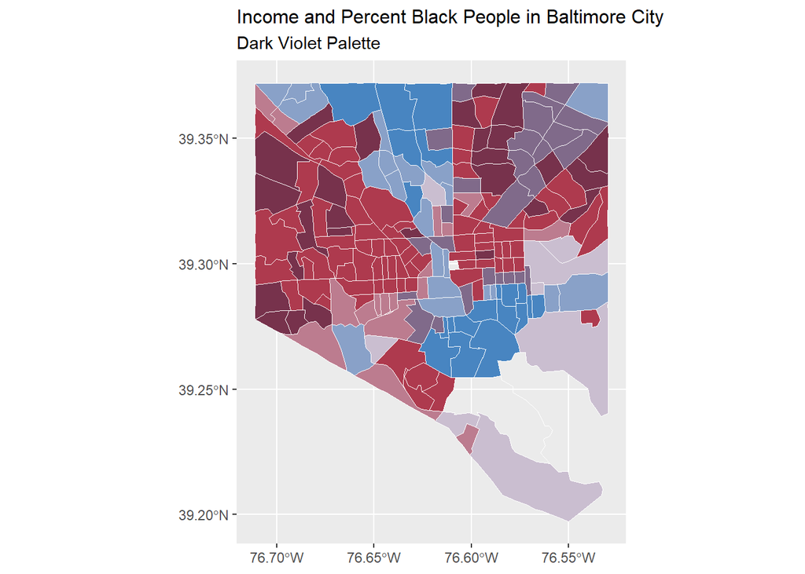

```r
plot(bivariate)
```

**6. Use the cowplot package and ggdraw, like in the tutorial to add a legend (2 points)**.

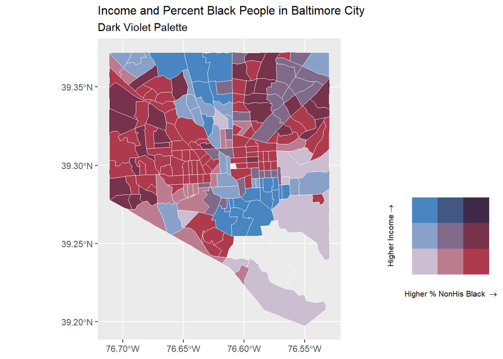

```r
# Create the legend
legend = bi_legend(pal = "DkViolet",
                    dim = 3,
                    xlab = " Higher % NonHis Black ",
                    ylab = " Higher Income ",
                    size = 8)

# Install cowplot if you haven't already
library(cowplot)
Final_map = ggdraw() +
  draw_plot(bivariate, 0, 0, .8, 1) +
  draw_plot(legend, .70, .15, 0.35, 0.35)

plot(Final_map)
```

**7. Rinse and repeat for another county of your choosing, using a *different* color scheme. Be sure to use Psuedo-Mercator (3857). (5 points)**

```r
Howard_income_race = get_acs(geography = "tract",
      variables = c("total_pop" = "B03002_001",# Total population
                    "Blck_NonH" = "B03002_004", # Non-Hispanic Black population
                    "income" = "B19013_001"), # Median household income
      year = 2019,
survey = "acs5",
state = c(24),  # FIPS code for Maryland
county = c(027), # FIPS code for Baltimore City
geometry = TRUE,
output = "wide")
# Compute the percent of the population that is Black.
Howard_income_race$Percent_Blck = (Howard_income_race$Blck_NonHE / Howard_income_race$total_popE)

# Create a sf object.
st_as_sf(Howard_income_race)
```

```
## Simple feature collection with 55 features and 9 fields
## geometry type:  MULTIPOLYGON
## dimension:      XY
## bbox:           xmin: -77.18711 ymin: 39.10314 xmax: -76.69677 ymax: 39.36932
## geographic CRS: NAD83
## First 10 features:
##          GEOID                                          NAME total_popE
## 1  24027605504 Census Tract 6055.04, Howard County, Maryland       2650
## 2  24027606607 Census Tract 6066.07, Howard County, Maryland       4760
## 3  24027606704 Census Tract 6067.04, Howard County, Maryland       6899
## 4  24027601203 Census Tract 6012.03, Howard County, Maryland       7315
## 5  24027605401 Census Tract 6054.01, Howard County, Maryland       5250
## 6  24027605601 Census Tract 6056.01, Howard County, Maryland       6495
## 7  24027606803 Census Tract 6068.03, Howard County, Maryland       5452
## 8  24027606705 Census Tract 6067.05, Howard County, Maryland       2030
```

[output cut: 24 more lines]